# Multiple Linear Regression on Customer Data

Insofe Lab Session

June 18 , 2017

```r
# Go through the data and understand the attributes to get the info of the variables.
```

Write a code to clear the environment if needed

```r
rm(list=ls(all=TRUE))
```

Write a code to set the working directory.

```r
setwd("D:/AcademicsWork/Regression")
```

Think and load the libraries as and when required in this place only as best practice

```r
library(corrplot)
library(DMwR)
library(vegan)
library(MASS)
library(car)
library(caret)
```

Write a code to read the csv file as “data” as per required

```r
data<-read.csv(file = "20170618_Batch29_CSE7302c_CustomerData_Assignment.csv",header = TRUE,sep = ",")
```

Write a code to know the names of the attributes

```r
names(data)
```

```
##  [1] "CustomerID"                   "City"
##  [3] "NoOfChildren"                 "MinAgeOfChild"
##  [5] "MaxAgeOfChild"                "Tenure"
##  [7] "FrquncyOfPurchase"            "NoOfUnitsPurchased"
##  [9] "FrequencyOFPlay"              "NoOfGamesPlayed"
## [11] "NoOfGamesBought"              "FavoriteChannelOfTransaction"
## [13] "FavoriteGame"                 "TotalRevenueGenerated"
```

Write a code to find the dimensions of the data

```r
nrow(data)
```

```
## [1] 3209
```

```r
ncol(data)
```

```
## [1] 14
```

Write a code to see the head and tail of the dataset atleast 10rows

```r
head(data,10)
```

```
##    CustomerID City NoOfChildren MinAgeOfChild MaxAgeOfChild Tenure
## 1        1001    1            2             3             8    210
## 2        1002    1            2             3             6    442
## 3        1003    1            4             3             5    424
## 4        1004    1            1             6             6    261
## 5        1005    1            3             6             9    422
## 6        1006    1            2             3             4    378
## 7        1007    1            3             8            12    369
## 8        1008    1            2             6             8    404
## 9        1009    1            4             6             9    420
## 10       1010    2            3             5             6    333
##    FrquncyOfPurchase NoOfUnitsPurchased FrequencyOFPlay NoOfGamesPlayed
## 1                 11                 11            2344             108
## 2                 20                 20             245              22
## 3                 18                 18            1059             130
```

[output cut: 29 more lines]

```r
tail(data,10)
```

```
##      CustomerID City NoOfChildren MinAgeOfChild MaxAgeOfChild Tenure
## 3200       4200    1            1             6             6    352
## 3201       4201    1            2             7             8    313
## 3202       4202    1            3             2             6    424
## 3203       4203    1            2             5             7    424
## 3204       4204    1            1             4             4    431
## 3205       4205    1            2             4             6    365
## 3206       4206    1            2             2             5    348
## 3207       4207    1            2             5             7    341
## 3208       4208    1            2             6             7    368
## 3209       4209    1            3             2             6    389
##      FrquncyOfPurchase NoOfUnitsPurchased FrequencyOFPlay NoOfGamesPlayed
## 3200                27                 24            2042             194
## 3201                15                 15             952             113
## 3202                20                 12            2038             177
```

[output cut: 29 more lines]

Write a code to see the data types of the attributes

```r
str(data)
```

```
## 'data.frame':    3209 obs. of  14 variables:
##  $ CustomerID                  : int  1001 1002 1003 1004 1005 1006 1007 1008 1009 1010 ...
##  $ City                        : int  1 1 1 1 1 1 1 1 1 2 ...
##  $ NoOfChildren                : int  2 2 4 1 3 2 3 2 4 3 ...
##  $ MinAgeOfChild               : int  3 3 3 6 6 3 8 6 6 5 ...
##  $ MaxAgeOfChild               : int  8 6 5 6 9 4 12 8 9 6 ...
##  $ Tenure                      : int  210 442 424 261 422 378 369 404 420 333 ...
##  $ FrquncyOfPurchase           : int  11 20 18 11 44 16 25 13 20 15 ...
##  $ NoOfUnitsPurchased          : int  11 20 18 9 31 16 15 12 16 15 ...
##  $ FrequencyOFPlay             : int  2344 245 1059 365 1066 228 75 1488 2743 1967 ...
##  $ NoOfGamesPlayed             : int  108 22 130 34 102 12 2 118 163 56 ...
##  $ NoOfGamesBought             : int  10 7 18 11 44 16 25 13 16 15 ...
##  $ FavoriteChannelOfTransaction: Factor w/ 2 levels "Favorite","Uniform": 2 1 1 1 2 1 1 1 2 1 ...
##  $ FavoriteGame                : Factor w/ 3 levels "Favorite","NONE",..: 3 3 3 3 3 1 1 3 3 3 ...
##  $ TotalRevenueGenerated       : num  108 382 135 125 335 ...
```

Write a code to remove the unuseful variables and store the data

```r
data$CustomerID<-NULL
```

Write a code to observe the variables and convert them into the required formats

```r
data$City<-as.factor(data$City)
```

Check the changes again using str() command

```r
str(data)
```

```
## 'data.frame':    3209 obs. of  13 variables:
##  $ City                        : Factor w/ 2 levels "1","2": 1 1 1 1 1 1 1 1 1 2 ...
##  $ NoOfChildren                : int  2 2 4 1 3 2 3 2 4 3 ...
##  $ MinAgeOfChild               : int  3 3 3 6 6 3 8 6 6 5 ...
##  $ MaxAgeOfChild               : int  8 6 5 6 9 4 12 8 9 6 ...
##  $ Tenure                      : int  210 442 424 261 422 378 369 404 420 333 ...
##  $ FrquncyOfPurchase           : int  11 20 18 11 44 16 25 13 20 15 ...
##  $ NoOfUnitsPurchased          : int  11 20 18 9 31 16 15 12 16 15 ...
##  $ FrequencyOFPlay             : int  2344 245 1059 365 1066 228 75 1488 2743 1967 ...
##  $ NoOfGamesPlayed             : int  108 22 130 34 102 12 2 118 163 56 ...
##  $ NoOfGamesBought             : int  10 7 18 11 44 16 25 13 16 15 ...
##  $ FavoriteChannelOfTransaction: Factor w/ 2 levels "Favorite","Uniform": 2 1 1 1 2 1 1 1 2 1 ...
##  $ FavoriteGame                : Factor w/ 3 levels "Favorite","NONE",..: 3 3 3 3 3 1 1 3 3 3 ...
##  $ TotalRevenueGenerated       : num  108 382 135 125 335 ...
```

Write a Code to seperate the target

```r
target<-data$TotalRevenueGenerated
```

Write a code to get the numerical attributes out and store them as data_num

```r
data_num<-subset(x = data,select = -c(FavoriteChannelOfTransaction,FavoriteGame,City,TotalRevenueGenerated))
head(data_num)
```

```
##   NoOfChildren MinAgeOfChild MaxAgeOfChild Tenure FrquncyOfPurchase
## 1            2             3             8    210                11
## 2            2             3             6    442                20
## 3            4             3             5    424                18
## 4            1             6             6    261                11
## 5            3             6             9    422                44
## 6            2             3             4    378                16
##   NoOfUnitsPurchased FrequencyOFPlay NoOfGamesPlayed NoOfGamesBought
## 1                 11            2344             108              10
## 2                 20             245              22               7
## 3                 18            1059             130              18
## 4                  9             365              34              11
## 5                 31            1066             102              44
## 6                 16             228              12              16
```

Write a code for Normalizing the data_num

```r
data_num_std<-decostand(data_num,"normalize",2)
summary(data_num_std)
```

```
##   NoOfChildren      MinAgeOfChild     MaxAgeOfChild         Tenure
##  Min.   :0.007459   Min.   :0.00000   Min.   :0.00446   Min.   :0.004916
##  1st Qu.:0.007459   1st Qu.:0.01139   1st Qu.:0.00892   1st Qu.:0.014796
##  Median :0.014918   Median :0.01424   Median :0.01041   Median :0.018090
##  Mean   :0.015876   Mean   :0.01413   Mean   :0.01188   Mean   :0.017083
##  3rd Qu.:0.022377   3rd Qu.:0.01709   3rd Qu.:0.01189   3rd Qu.:0.020498
##  Max.   :0.082048   Max.   :0.32191   Max.   :0.16800   Max.   :0.023202
##  FrquncyOfPurchase   NoOfUnitsPurchased FrequencyOFPlay
##  Min.   :0.0009631   Min.   :0.00108    Min.   :0.000000
##  1st Qu.:0.0105945   1st Qu.:0.01080    1st Qu.:0.003287
##  Median :0.0134838   Median :0.01404    Median :0.007584
##  Mean   :0.0156697   Mean   :0.01586    Mean   :0.011558
##  3rd Qu.:0.0182995   3rd Qu.:0.01836    3rd Qu.:0.014954
##  Max.   :0.1146126   Max.   :0.12096    Max.   :0.205109
##  NoOfGamesPlayed    NoOfGamesBought
##  Min.   :0.000000   Min.   :0.00000
##  1st Qu.:0.005058   1st Qu.:0.01028
##  Median :0.009570   Median :0.01439
##  Mean   :0.012800   Mean   :0.01518
##  3rd Qu.:0.016269   3rd Qu.:0.01953
##  Max.   :0.159405   Max.   :0.11822
```

Write a code to observe the correlation between the attributes

```r
cor(data_num_std)
```

```
##                    NoOfChildren MinAgeOfChild MaxAgeOfChild      Tenure
## NoOfChildren          1.0000000 -0.1791759583   0.189001961  0.08534060
## MinAgeOfChild        -0.1791760  1.0000000000   0.367127367 -0.05582027
## MaxAgeOfChild         0.1890020  0.3671273667   1.000000000 -0.04032911
## Tenure                0.0853406 -0.0558202691  -0.040329109  1.00000000
## FrquncyOfPurchase     0.1376303 -0.0175678432  -0.006212834  0.19334370
## NoOfUnitsPurchased    0.1370396 -0.0061912434  -0.003925588  0.19241309
## FrequencyOFPlay       0.1650357  0.0066897624   0.012095286  0.24180938
## NoOfGamesPlayed       0.2133424  0.0001039156   0.027946580  0.27369597
## NoOfGamesBought       0.1313984 -0.0077484225  -0.007062492  0.18828481
##                    FrquncyOfPurchase NoOfUnitsPurchased FrequencyOFPlay
## NoOfChildren             0.137630281        0.137039620     0.165035716
## MinAgeOfChild           -0.017567843       -0.006191243     0.006689762
## MaxAgeOfChild           -0.006212834       -0.003925588     0.012095286
## Tenure                   0.193343704        0.192413092     0.241809378
## FrquncyOfPurchase        1.000000000        0.934130532     0.279957433
## NoOfUnitsPurchased       0.934130532        1.000000000     0.311981695
## FrequencyOFPlay          0.279957433        0.311981695     1.000000000
## NoOfGamesPlayed          0.397566861        0.436149179     0.740204301
## NoOfGamesBought          0.947787464        0.868374420     0.286943164
##                    NoOfGamesPlayed NoOfGamesBought
## NoOfChildren          0.2133424389     0.131398358
## MinAgeOfChild         0.0001039156    -0.007748422
## MaxAgeOfChild         0.0279465799    -0.007062492
## Tenure                0.2736959714     0.188284813
## FrquncyOfPurchase     0.3975668611     0.947787464
## NoOfUnitsPurchased    0.4361491791     0.868374420
## FrequencyOFPlay       0.7402043013     0.286943164
## NoOfGamesPlayed       1.0000000000     0.399178320
## NoOfGamesBought       0.3991783197     1.000000000
```

Write a code to plot the corrplot of correlation between the attributes

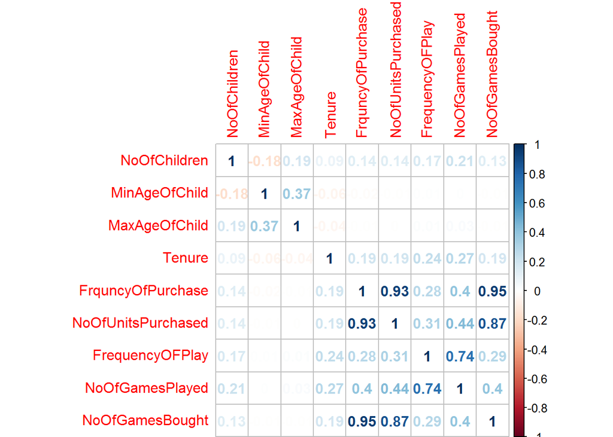

```r
corrplot(cor(data_num_std),method = 'number')
```

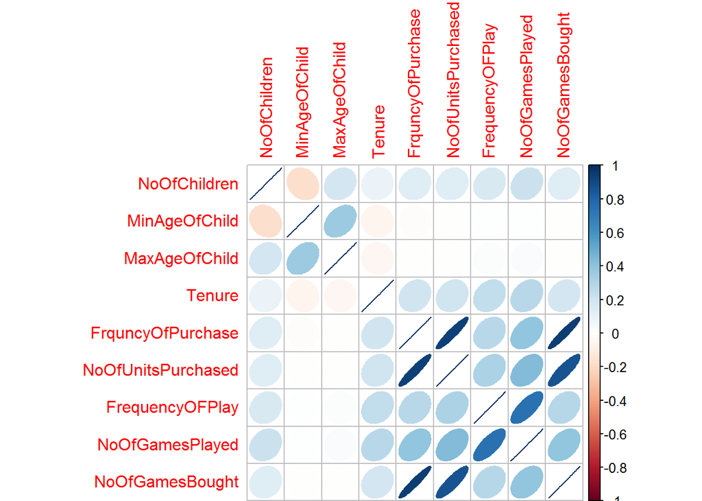

```r
corrplot(cor(data_num_std),method = 'ellipse')
```

Write a code to seperate the categorical attributes

```r
data_cat<-data[,c(1,11,12)]
```

Write a code to combine the numerical,categorical data along with the target

```r
data_updated<-cbind(data_num_std,data_cat,target)
str(data_updated)
```

```
## 'data.frame':    3209 obs. of  13 variables:
##  $ NoOfChildren                : num  0.01492 0.01492 0.02984 0.00746 0.02238 ...
##  $ MinAgeOfChild               : num  0.00855 0.00855 0.00855 0.01709 0.01709 ...
##  $ MaxAgeOfChild               : num  0.01189 0.00892 0.00743 0.00892 0.01338 ...
##  $ Tenure                      : num  0.0103 0.0217 0.0208 0.0128 0.0207 ...
##  $ FrquncyOfPurchase           : num  0.0106 0.0193 0.0173 0.0106 0.0424 ...
##  $ NoOfUnitsPurchased          : num  0.01188 0.0216 0.01944 0.00972 0.03348 ...
##  $ FrequencyOFPlay             : num  0.01728 0.00181 0.00781 0.00269 0.00786 ...
##  $ NoOfGamesPlayed             : num  0.01476 0.00301 0.01777 0.00465 0.01394 ...
##  $ NoOfGamesBought             : num  0.0103 0.0072 0.0185 0.0113 0.0452 ...
##  $ City                        : Factor w/ 2 levels "1","2": 1 1 1 1 1 1 1 1 1 2 ...
##  $ FavoriteChannelOfTransaction: Factor w/ 2 levels "Favorite","Uniform": 2 1 1 1 2 1 1 1 2 1 ...
##  $ FavoriteGame                : Factor w/ 3 levels "Favorite","NONE",..: 3 3 3 3 3 1 1 3 3 3 ...
##  $ target                      : num  108 382 135 125 335 ...
```

Write a code to set the seed and comment why it is used.

```r
set.seed(123)
```

Write a code to get the train rows using sample

```r
rows=seq(1,nrow(data_updated),1)
trainRows=sample(rows,(70*nrow(data_updated))/100)
```

Write a code to get the train and test

```r
train = data_updated[trainRows,]
test = data_updated[-trainRows,]
```

Write a code to just plot the grahs between attributes and targets

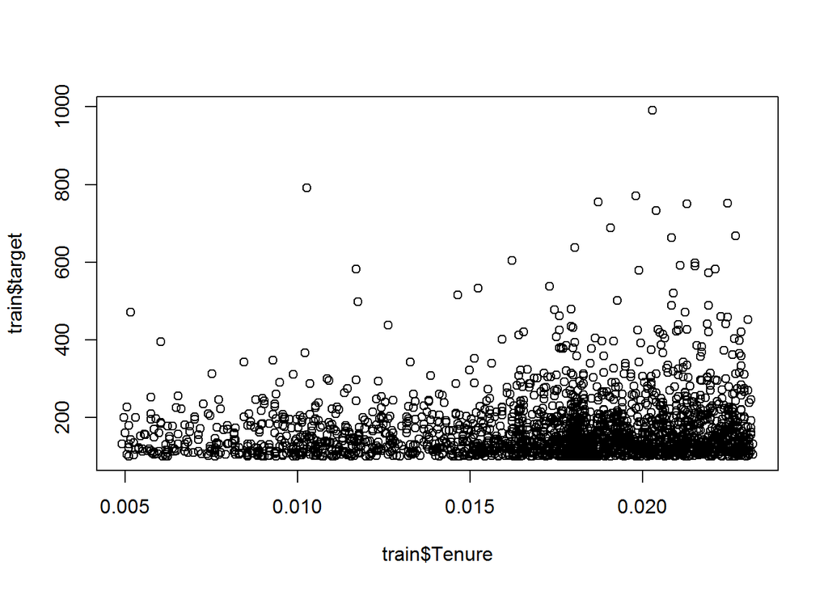

```r
plot(train$Tenure,train$target)
```

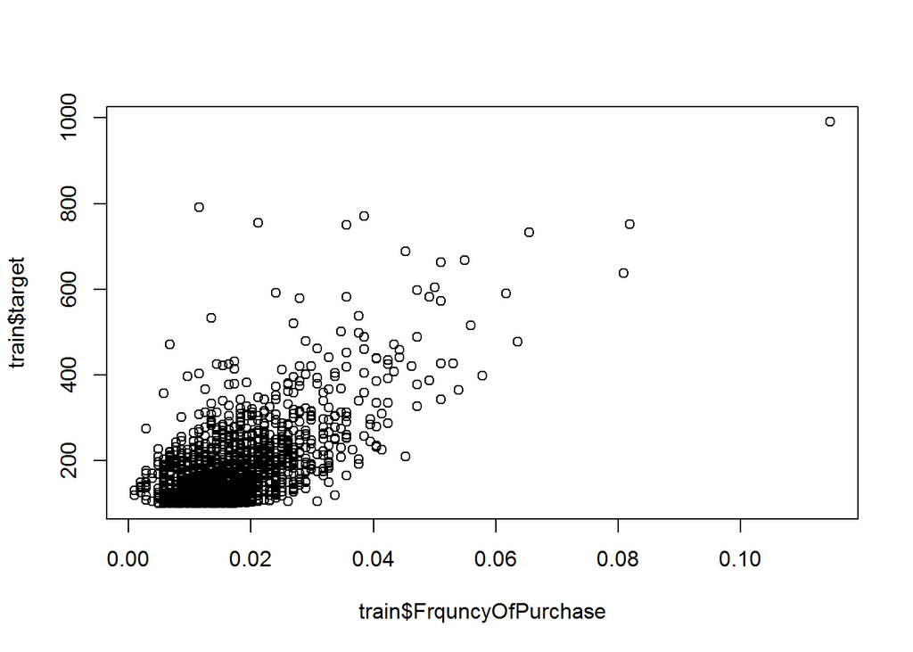

```r
plot(train$FrquncyOfPurchase,train$target)
```

Write a code to form a linear regression model

```r
model_lm=lm(train$target~.,data=train)
```

Write a code to plot the model

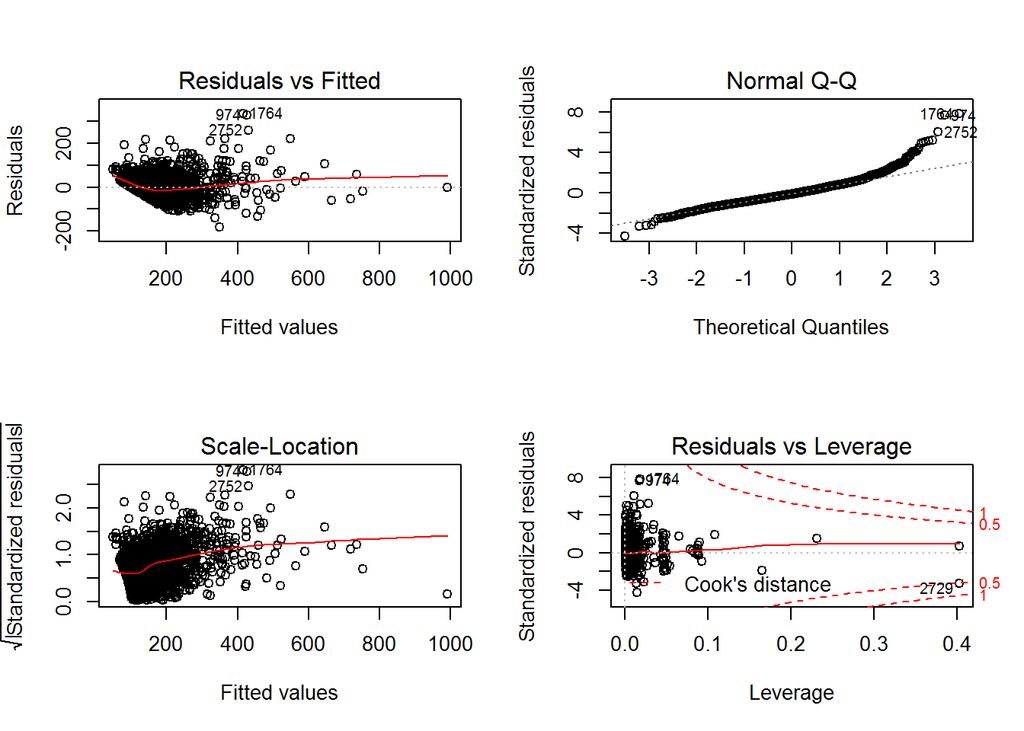

```r
par(mfrow=c(2,2))
plot(model_lm)
```

Write a code to check the summary of the model

```r
summary(model_lm)
```

```
##
## Call:
## lm(formula = train$target ~ ., data = train)
##
## Residuals:
##     Min      1Q  Median      3Q     Max
## -181.78  -26.40   -4.12   22.06  333.99
##
## Coefficients:
##                                       Estimate Std. Error t value Pr(>|t|)
## (Intercept)                             38.750      6.313   6.138 9.84e-10
## NoOfChildren                           271.835    126.907   2.142  0.03230
## MinAgeOfChild                          320.777     98.247   3.265  0.00111
## MaxAgeOfChild                          -63.671     81.023  -0.786  0.43204
## Tenure                                -402.837    214.490  -1.878  0.06050
## FrquncyOfPurchase                    11117.148    523.709  21.228  < 2e-16
## NoOfUnitsPurchased                    8607.348    340.213  25.300  < 2e-16
## FrequencyOFPlay                        302.486     95.968   3.152  0.00164
## NoOfGamesPlayed                        -32.126    116.720  -0.275  0.78315
## NoOfGamesBought                     -11492.256    342.661 -33.538  < 2e-16
## City2                                    8.885      2.982   2.980  0.00292
## FavoriteChannelOfTransactionUniform    -15.532      2.434  -6.381 2.13e-10
## FavoriteGameNONE                        -4.646     10.358  -0.449  0.65383
## FavoriteGameUniform                     -9.709      4.915  -1.975  0.04836
##
## (Intercept)                         ***
## NoOfChildren                        *
## MinAgeOfChild                       **
## MaxAgeOfChild
## Tenure                              .
## FrquncyOfPurchase                   ***
## NoOfUnitsPurchased                  ***
## FrequencyOFPlay                     **
## NoOfGamesPlayed
## NoOfGamesBought                     ***
## City2                               **
## FavoriteChannelOfTransactionUniform ***
## FavoriteGameNONE
## FavoriteGameUniform                 *
## ---
## Signif. codes:  0 '***' 0.001 '**' 0.01 '*' 0.05 '.' 0.1 ' ' 1
##
## Residual standard error: 42.89 on 2232 degrees of freedom
## Multiple R-squared:  0.741,  Adjusted R-squared:  0.7395
## F-statistic: 491.3 on 13 and 2232 DF,  p-value: < 2.2e-16
```

Write a code to predict the value of the target on the linear model

```r
pred_lm<-predict(model_lm,test)
```

Write a code to use stepAIC

```r
model_AIC<-stepAIC(model_lm)
```

```
## Start:  AIC=16897.76
## train$target ~ NoOfChildren + MinAgeOfChild + MaxAgeOfChild +
##     Tenure + FrquncyOfPurchase + NoOfUnitsPurchased + FrequencyOFPlay +
##     NoOfGamesPlayed + NoOfGamesBought + City + FavoriteChannelOfTransaction +
##     FavoriteGame
##
##                                Df Sum of Sq     RSS   AIC
## - NoOfGamesPlayed               1       139 4106018 16896
## - MaxAgeOfChild                 1      1136 4107015 16896
## <none>                                      4105879 16898
## - FavoriteGame                  2      7546 4113425 16898
## - Tenure                        1      6489 4112367 16899
## - NoOfChildren                  1      8440 4114319 16900
## - City                          1     16332 4122211 16905
## - FrequencyOFPlay               1     18276 4124154 16906
## - MinAgeOfChild                 1     19610 4125488 16907
## - FavoriteChannelOfTransaction  1     74913 4180792 16936
## - FrquncyOfPurchase             1    828932 4934810 17309
## - NoOfUnitsPurchased            1   1177467 5283345 17462
## - NoOfGamesBought               1   2069160 6175039 17812
##
## Step:  AIC=16895.84
## train$target ~ NoOfChildren + MinAgeOfChild + MaxAgeOfChild +
##     Tenure + FrquncyOfPurchase + NoOfUnitsPurchased + FrequencyOFPlay +
##     NoOfGamesBought + City + FavoriteChannelOfTransaction + FavoriteGame
##
##                                Df Sum of Sq     RSS   AIC
## - MaxAgeOfChild                 1      1131 4107149 16895
## <none>                                      4106018 16896
## - FavoriteGame                  2      7738 4113756 16896
## - Tenure                        1      6760 4112778 16898
## - NoOfChildren                  1      8305 4114323 16898
## - City                          1     16322 4122340 16903
## - MinAgeOfChild                 1     19604 4125622 16905
## - FrequencyOFPlay               1     27927 4133945 16909
## - FavoriteChannelOfTransaction  1     75316 4181334 16935
## - FrquncyOfPurchase             1    839361 4945379 17312
## - NoOfUnitsPurchased            1   1205158 5311176 17472
## - NoOfGamesBought               1   2096862 6202880 17820
##
## Step:  AIC=16894.46
## train$target ~ NoOfChildren + MinAgeOfChild + Tenure + FrquncyOfPurchase +
##     NoOfUnitsPurchased + FrequencyOFPlay + NoOfGamesBought +
##     City + FavoriteChannelOfTransaction + FavoriteGame
##
##                                Df Sum of Sq     RSS   AIC
## <none>                                      4107149 16895
## - FavoriteGame                  2      7902 4115051 16895
## - Tenure                        1      6568 4113717 16896
## - NoOfChildren                  1      7238 4114387 16896
## - City                          1     16474 4123623 16901
## - MinAgeOfChild                 1     19298 4126446 16903
## - FrequencyOFPlay               1     28255 4135404 16908
## - FavoriteChannelOfTransaction  1     75467 4182616 16933
## - FrquncyOfPurchase             1    839357 4946505 17310
## - NoOfUnitsPurchased            1   1205909 5313058 17471
## - NoOfGamesBought               1   2096789 6203937 17819
```

Write a code to predict it on stepAIC

```r
pred_AIC<-predict(model_AIC,test)
```

Write a code to check the multicollinearity in the lm model

```r
vif(model_lm)
```

```
##                                   GVIF Df GVIF^(1/(2*Df))
## NoOfChildren                  1.184375  1        1.088290
## MinAgeOfChild                 1.273206  1        1.128364
## MaxAgeOfChild                 1.270693  1        1.127250
## Tenure                        1.101558  1        1.049551
## FrquncyOfPurchase            23.358579  1        4.833071
## NoOfUnitsPurchased            9.110419  1        3.018347
## FrequencyOFPlay               2.046243  1        1.430470
## NoOfGamesPlayed               2.409533  1        1.552267
## NoOfGamesBought              12.100235  1        3.478539
## City                          1.077669  1        1.038108
## FavoriteChannelOfTransaction  1.085359  1        1.041805
## FavoriteGame                  1.072610  2        1.017678
```

Write a code to check the plots of the models

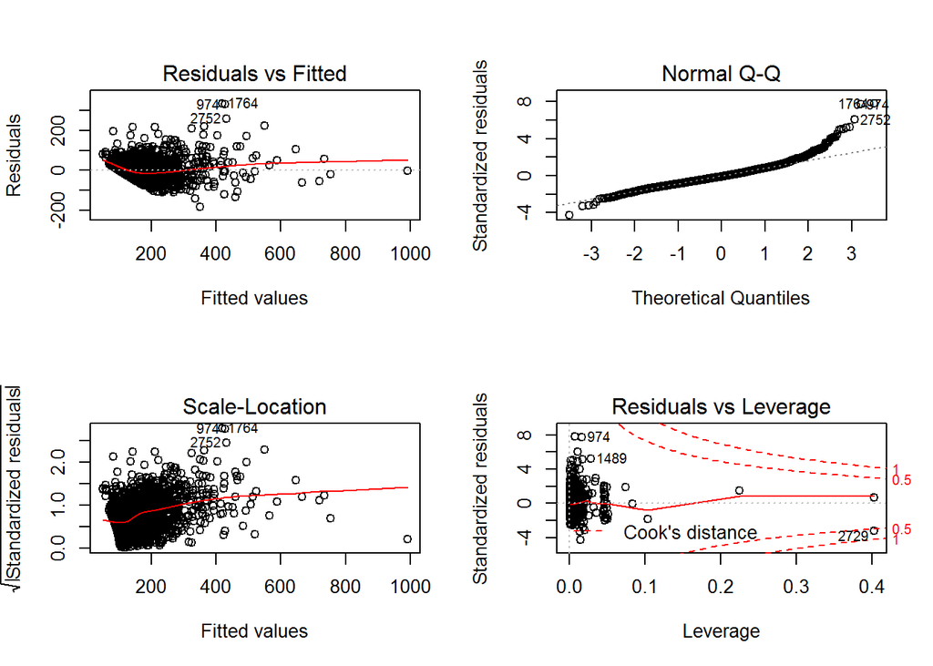

```r
par(mfrow=c(2,2))
plot(model_AIC)
```

Write a code to check the multicollinearity problem

```r
vif(model_AIC)
```

```
##                                   GVIF Df GVIF^(1/(2*Df))
## NoOfChildren                  1.075963  1        1.037286
## MinAgeOfChild                 1.042444  1        1.021001
## Tenure                        1.088261  1        1.043198
## FrquncyOfPurchase            23.127823  1        4.809140
## NoOfUnitsPurchased            8.868931  1        2.978075
## FrequencyOFPlay               1.191378  1        1.091503
## NoOfGamesBought              11.961376  1        3.458522
## City                          1.077343  1        1.037952
## FavoriteChannelOfTransaction  1.083385  1        1.040858
## FavoriteGame                  1.065795  2        1.016058
```

Write a code to evaluate the error in the prediction of AIC

```r
regr.eval(test$target,pred_AIC)
```

```
##          mae          mse         rmse         mape
##   31.9655908 2026.4851645   45.0164988    0.1888975
```

Write a code to evaluate the error on the prediction of Linear Regression

```r
regr.eval(test$target,pred_lm)
```

```
##          mae          mse         rmse         mape
##   31.9459866 2021.1599577   44.9573126    0.1888768
```